# Premier League Data Analysis

```python
df2 = pd.read_csv('stats.csv')
```

```python
df2 = df2.dropna(axis = 1)
```

```python
win = df2.groupby('team').mean().sort_values('wins', ascending = True).tail(10)
```

```python
column_list = list(df2.columns)
column_list.remove('team')
column_list.remove('season')
```

In order to have a deeper understanding of the data, we chose every top 10 in terms of average statistics for each factor and visualize them in different tables. Interestingly, Liverpool is the unluckiest team of the League so far as their balls hit the woodwork the most, whereas Manchester United has had the best defense class because of the highest clean sheets rate in many seasons.

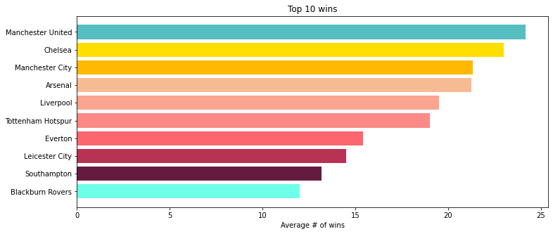

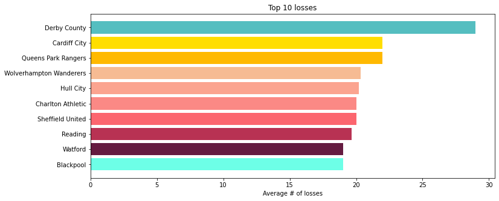

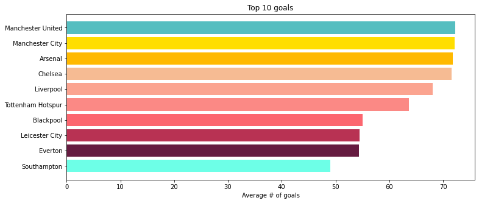

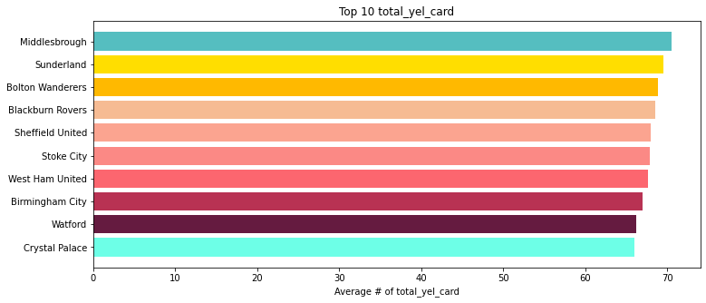

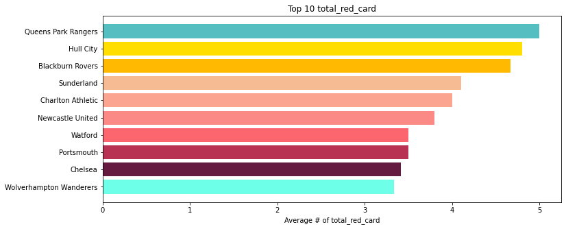

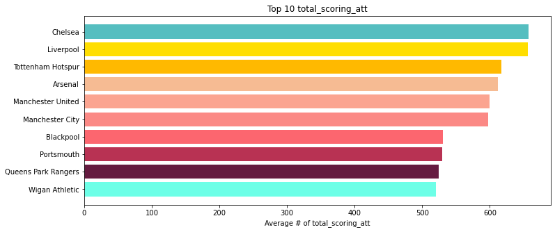

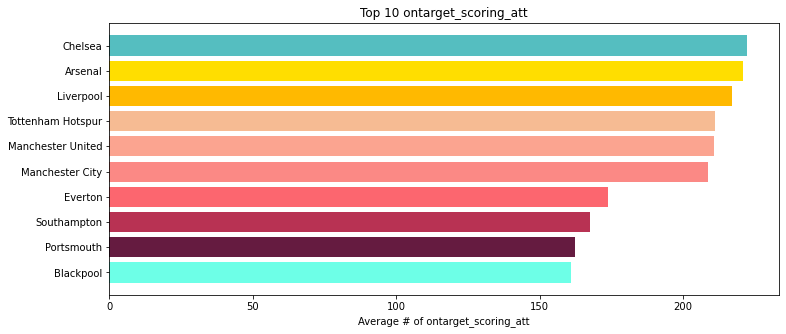

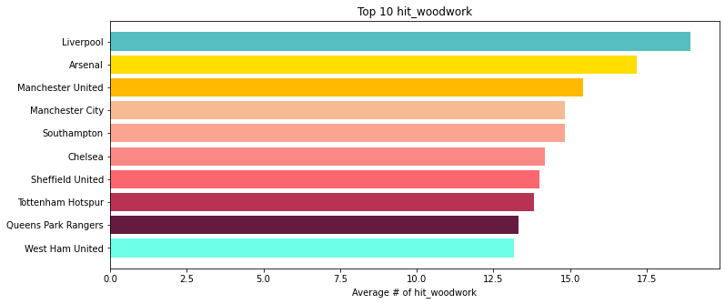

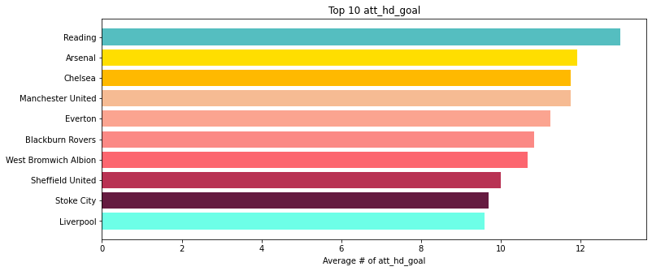

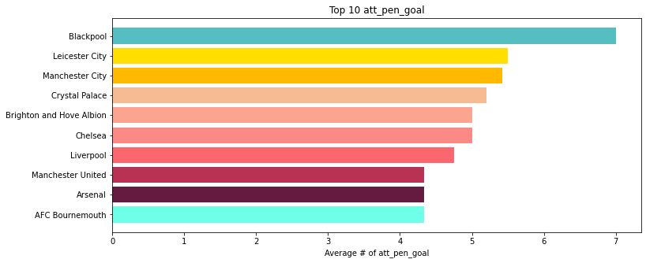

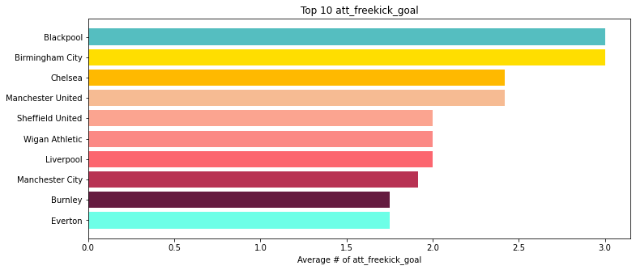

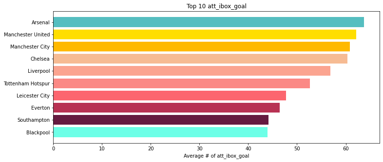

[22 more figures not shown]

```python
for column in column_list:
    x = df2.groupby('team').mean().sort_values(column, ascending = True).tail(10)
    plt.figure(figsize = (12,5))
    plt.barh(x.index, x[column],color=['#6DFFE7','#651B40','#B83253','#FC666F','#FB8985','#FBA490','#F6BB93','#FFB900','#FFDE00','#55BEC0'])
    plt.title('Top 10'+ " " + column)
    plt.xlabel('Average # of' + " " + column)
    plt.show()
```

We also run the correlation between those factors to have a better understanding about their relationship.